# SIF LAI comparison

D. Emin

December 19, 2018

## Introduction

Descriptive statistics of HyPlant SIF data was shown in another document. The procedure to retrieve LAI and Chl were described in another document. Here we will explore the relationship between canopy structure (LAI, CHL, VI) and SIF (760, 687, ratio, total). Furthermore, we will explore the shape and the strength of these relatioships across scales.

HyPlant occupies an intermediate scale. Used to study the regional variability of SIF. It produces a nominal spatial resolution of 1 m2 - high enough to study the within field variability of SIF

this analysis is based on one agricultural crop - sugar beet, grown on 59 fields.

## Nominal scale

### SIF vs canopy structure

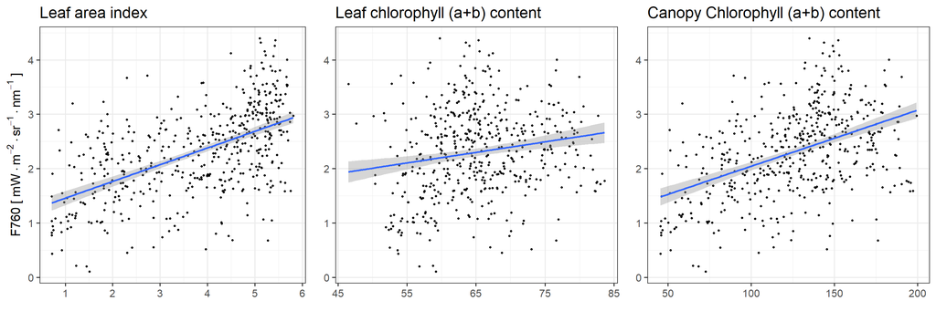

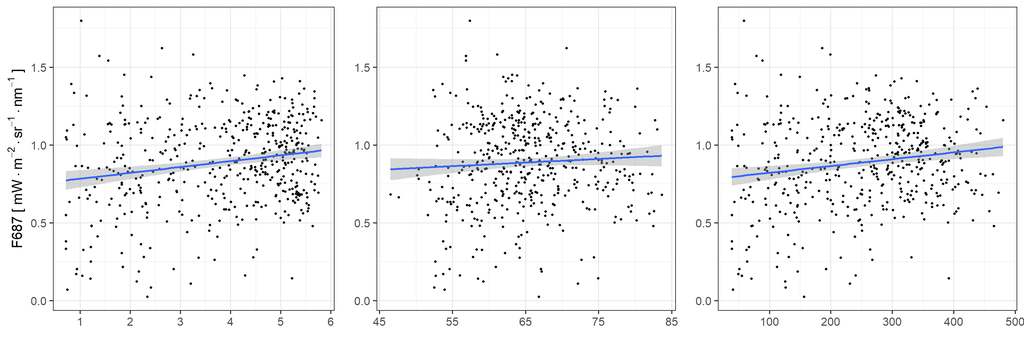

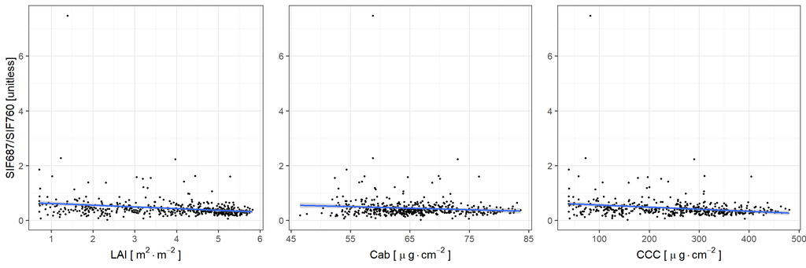

### SIF vs VI

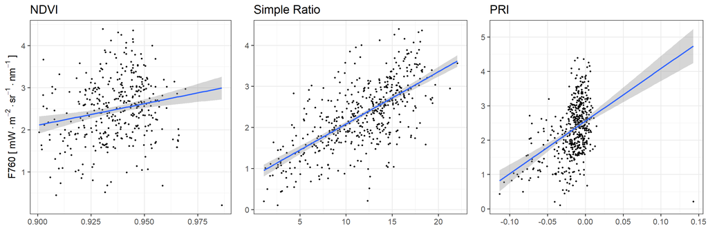

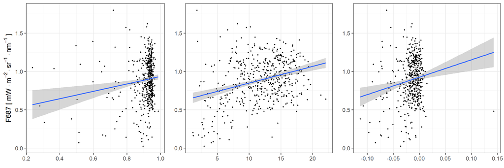

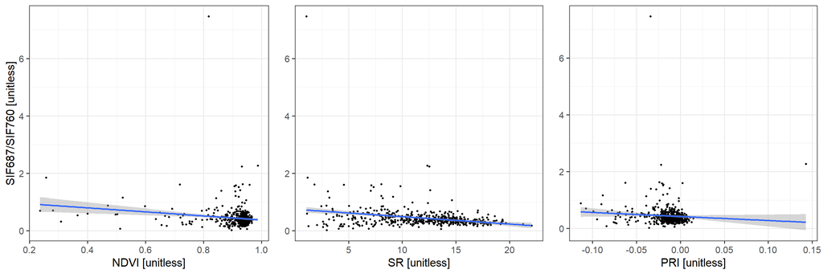

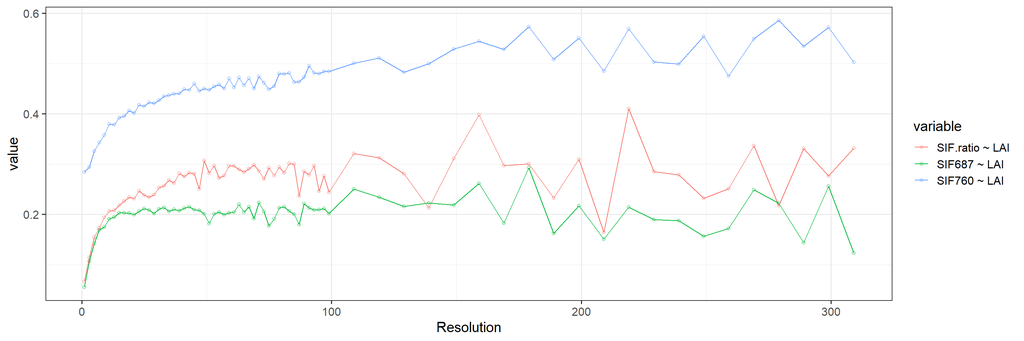

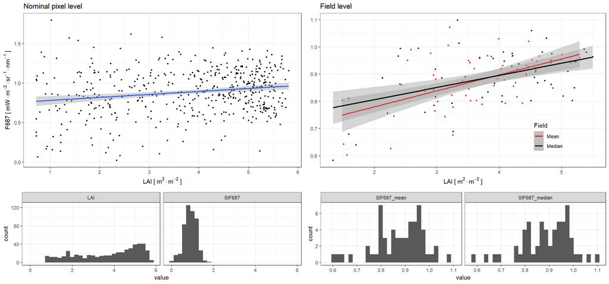

There is a negative relationship between SIF ration (SIF687 / SIF760) and LAI. This is obvious since SIF 687 (the nominator) changes less than SIF760 (denominator) leading to a smaller ratio with bigger LAI.